# Part I - (Loan Data Visualization)

## Introduction

> The dataset i will be working with for this project is the Prosper Loan Data which contains different determinant factors that can affect loan outcome. The data contains 113937 rows and 81 columns.

> Through my research for this project one thing that helped me understand this data well is the data variable definitions which i have attached below. https://docs.google.com/spreadsheets/d/1gDyi_L4UvIrLTEC6Wri5nbaMmkGmLQBk-Yx3z0XDEtI/edit?usp=sharing

## Preliminary Wrangling

```python
# import all packages and set plots to be embedded inline
import numpy as np
import pandas as pd
import matplotlib.pyplot as plt
import seaborn as sb

%matplotlib inline
```

> Load in your dataset and describe its properties through the questions below. Try and motivate your exploration goals through this section.

```python
#load the dataset into a pandas dataframe
df_loan = pd.read_csv('prosperLoanData.csv')

df_loan.head()
```

|  | ListingKey | ListingNumber | ListingCreationDate | CreditGrade | Term | LoanStatus | ClosedDate | BorrowerAPR | BorrowerRate | LenderYield | ... | LP_ServiceFees | LP_CollectionFees | LP_GrossPrincipalLoss | LP_NetPrincipalLoss | LP_NonPrincipalRecoverypayments | PercentFunded | Recommendations | InvestmentFromFriendsCount | InvestmentFromFriendsAmount | Investors |
| --- | --- | --- | --- | --- | --- | --- | --- | --- | --- | --- | --- | --- | --- | --- | --- | --- | --- | --- | --- | --- | --- |
| 0 | 1021339766868145413AB3B | 193129 | 2007-08-26 19:09:29.263000000 | C | 36 | Completed | 2009-08-14 00:00:00 | 0.16516 | 0.1580 | 0.1380 | ... | -133.18 | 0.0 | 0.0 | 0.0 | 0.0 | 1.0 | 0 | 0 | 0.0 | 258 |
| 1 | 10273602499503308B223C1 | 1209647 | 2014-02-27 08:28:07.900000000 | NaN | 36 | Current | NaN | 0.12016 | 0.0920 | 0.0820 | ... | 0.00 | 0.0 | 0.0 | 0.0 | 0.0 | 1.0 | 0 | 0 | 0.0 | 1 |
| 2 | 0EE9337825851032864889A | 81716 | 2007-01-05 15:00:47.090000000 | HR | 36 | Completed | 2009-12-17 00:00:00 | 0.28269 | 0.2750 | 0.2400 | ... | -24.20 | 0.0 | 0.0 | 0.0 | 0.0 | 1.0 | 0 | 0 | 0.0 | 41 |
| 3 | 0EF5356002482715299901A | 658116 | 2012-10-22 11:02:35.010000000 | NaN | 36 | Current | NaN | 0.12528 | 0.0974 | 0.0874 | ... | -108.01 | 0.0 | 0.0 | 0.0 | 0.0 | 1.0 | 0 | 0 | 0.0 | 158 |
| 4 | 0F023589499656230C5E3E2 | 909464 | 2013-09-14 18:38:39.097000000 | NaN | 36 | Current | NaN | 0.24614 | 0.2085 | 0.1985 | ... | -60.27 | 0.0 | 0.0 | 0.0 | 0.0 | 1.0 | 0 | 0 | 0.0 | 20 |

5 rows × 81 columns

```python
#overview of the data information
df_loan.info()
```

```
<class 'pandas.core.frame.DataFrame'>
RangeIndex: 113937 entries, 0 to 113936
Data columns (total 81 columns):
ListingKey                             113937 non-null object
ListingNumber                          113937 non-null int64
ListingCreationDate                    113937 non-null object
CreditGrade                            28953 non-null object
Term                                   113937 non-null int64
LoanStatus                             113937 non-null object
ClosedDate                             55089 non-null object
BorrowerAPR                            113912 non-null float64
BorrowerRate                           113937 non-null float64
LenderYield                            113937 non-null float64
EstimatedEffectiveYield                84853 non-null float64
EstimatedLoss                          84853 non-null float64
EstimatedReturn                        84853 non-null float64
ProsperRating (numeric)                84853 non-null float64
ProsperRating (Alpha)                  84853 non-null object
ProsperScore                           84853 non-null float64
ListingCategory (numeric)              113937 non-null int64
BorrowerState                          108422 non-null object
Occupation                             110349 non-null object
EmploymentStatus                       111682 non-null object
EmploymentStatusDuration               106312 non-null float64
IsBorrowerHomeowner                    113937 non-null bool
CurrentlyInGroup                       113937 non-null bool
GroupKey                               13341 non-null object
DateCreditPulled                       113937 non-null object
CreditScoreRangeLower                  113346 non-null float64
CreditScoreRangeUpper                  113346 non-null float64
FirstRecordedCreditLine                113240 non-null object
CurrentCreditLines                     106333 non-null float64
OpenCreditLines                        106333 non-null float64
TotalCreditLinespast7years             113240 non-null float64
OpenRevolvingAccounts                  113937 non-null int64
OpenRevolvingMonthlyPayment            113937 non-null float64
InquiriesLast6Months                   113240 non-null float64
TotalInquiries                         112778 non-null float64
CurrentDelinquencies                   113240 non-null float64
AmountDelinquent                       106315 non-null float64
```

[output cut: 31 more lines]

```
LP_CustomerPayments                    113937 non-null float64
LP_CustomerPrincipalPayments           113937 non-null float64
LP_InterestandFees                     113937 non-null float64
LP_ServiceFees                         113937 non-null float64
LP_CollectionFees                      113937 non-null float64
LP_GrossPrincipalLoss                  113937 non-null float64
LP_NetPrincipalLoss                    113937 non-null float64
LP_NonPrincipalRecoverypayments        113937 non-null float64
PercentFunded                          113937 non-null float64
Recommendations                        113937 non-null int64
InvestmentFromFriendsCount             113937 non-null int64
InvestmentFromFriendsAmount            113937 non-null float64
Investors                              113937 non-null int64
dtypes: bool(3), float64(50), int64(11), object(17)
memory usage: 68.1+ MB
```

```python
df_loan.isnull().sum()
```

```
ListingKey                                  0
ListingNumber                               0
ListingCreationDate                         0
CreditGrade                             84984
Term                                        0
LoanStatus                                  0
ClosedDate                              58848
BorrowerAPR                                25
BorrowerRate                                0
LenderYield                                 0
EstimatedEffectiveYield                 29084
EstimatedLoss                           29084
EstimatedReturn                         29084
ProsperRating (numeric)                 29084
ProsperRating (Alpha)                   29084
ProsperScore                            29084
ListingCategory (numeric)                   0
BorrowerState                            5515
Occupation                               3588
EmploymentStatus                         2255
EmploymentStatusDuration                 7625
IsBorrowerHomeowner                         0
CurrentlyInGroup                            0
GroupKey                               100596
DateCreditPulled                            0
CreditScoreRangeLower                     591
CreditScoreRangeUpper                     591
FirstRecordedCreditLine                   697
CurrentCreditLines                       7604
OpenCreditLines                          7604
                                        ...
TotalProsperLoans                       91852
TotalProsperPaymentsBilled              91852
OnTimeProsperPayments                   91852
ProsperPaymentsLessThanOneMonthLate     91852
ProsperPaymentsOneMonthPlusLate         91852
ProsperPrincipalBorrowed                91852
ProsperPrincipalOutstanding             91852
ScorexChangeAtTimeOfListing             95009
LoanCurrentDaysDelinquent                   0
LoanFirstDefaultedCycleNumber           96985
LoanMonthsSinceOrigination                  0
LoanNumber                                  0
LoanOriginalAmount                          0
LoanOriginationDate                         0
LoanOriginationQuarter                      0
MemberKey                                   0
MonthlyLoanPayment                          0
LP_CustomerPayments                         0
LP_CustomerPrincipalPayments                0
LP_InterestandFees                          0
LP_ServiceFees                              0
LP_CollectionFees                           0
LP_GrossPrincipalLoss                       0
LP_NetPrincipalLoss                         0
LP_NonPrincipalRecoverypayments             0
PercentFunded                               0
Recommendations                             0
InvestmentFromFriendsCount                  0
InvestmentFromFriendsAmount                 0
Investors                                   0
Length: 81, dtype: int64
```

### What is the structure of your dataset?

> This dataset has 113937 entries for a loan and 81 columns for features and i'll have to select the ones I need as they are not all that useful

### What is/are the main feature(s) of interest in your dataset?

> I am most interested in finding out the factors that affect the outcome of a loan.

### What features in the dataset do you think will help support your investigation into your feature(s) of interest?

> Getting a loan involves series of decision making process that's why the dataset is quite cumbersome, i think features like the `LoanStatus` `Occupation` `EmploymentStatus` `IncomeRange` `EmploymentStatus` will be useful for my investigation. However, i believe as i carry on with my investigation i might find other useful features along the way.

```python
#as good practice, i'll be making copy of the original data before i begin cleaning

df_loan_clean = df_loan.copy()
```

```python
#Here i'll be selecting the columns needed for this project for not all the 81 columns are relevant to this project.
loan_clean = df_loan_clean.reindex(columns=('ListingNumber', 'ListingCreationDate', 'CreditGrade', 'Term',
                                  'LoanStatus', 'BorrowerAPR', 'BorrowerRate', 'LenderYield', 'ProsperRating (Alpha)',
                                   'ClosedDate', 'LoanOriginationDate', 'ProsperScore', 'AmountDelinquent',
                                  'ListingCategory (numeric)', 'BorrowerState', 'Occupation', 'EmploymentStatus',
                                  'IncomeRange', 'StatedMonthlyIncome', 'LoanOriginalAmount', 'MonthlyLoanPayment',
                                  'Investors'))

loan_clean.info()
```

```
<class 'pandas.core.frame.DataFrame'>
RangeIndex: 113937 entries, 0 to 113936
Data columns (total 22 columns):
ListingNumber                113937 non-null int64
ListingCreationDate          113937 non-null object
CreditGrade                  28953 non-null object
Term                         113937 non-null int64
LoanStatus                   113937 non-null object
BorrowerAPR                  113912 non-null float64
BorrowerRate                 113937 non-null float64
LenderYield                  113937 non-null float64
ProsperRating (Alpha)        84853 non-null object
ClosedDate                   55089 non-null object
LoanOriginationDate          113937 non-null object
ProsperScore                 84853 non-null float64
AmountDelinquent             106315 non-null float64
ListingCategory (numeric)    113937 non-null int64
BorrowerState                108422 non-null object
Occupation                   110349 non-null object
EmploymentStatus             111682 non-null object
IncomeRange                  113937 non-null object
StatedMonthlyIncome          113937 non-null float64
LoanOriginalAmount           113937 non-null int64
MonthlyLoanPayment           113937 non-null float64
Investors                    113937 non-null int64
dtypes: float64(7), int64(5), object(10)
memory usage: 19.1+ MB
```

```python
#display some statistical info of the dataset
loan_clean.describe()
```

|  | ListingNumber | Term | BorrowerAPR | BorrowerRate | LenderYield | ProsperScore | AmountDelinquent | ListingCategory (numeric) | StatedMonthlyIncome | LoanOriginalAmount | MonthlyLoanPayment | Investors |
| --- | --- | --- | --- | --- | --- | --- | --- | --- | --- | --- | --- | --- |
| count | 1.139370e+05 | 113937.000000 | 113912.000000 | 113937.000000 | 113937.000000 | 84853.000000 | 106315.000000 | 113937.000000 | 1.139370e+05 | 113937.00000 | 113937.000000 | 113937.000000 |
| mean | 6.278857e+05 | 40.830248 | 0.218828 | 0.192764 | 0.182701 | 5.950067 | 984.507059 | 2.774209 | 5.608026e+03 | 8337.01385 | 272.475783 | 80.475228 |
| std | 3.280762e+05 | 10.436212 | 0.080364 | 0.074818 | 0.074516 | 2.376501 | 7158.270157 | 3.996797 | 7.478497e+03 | 6245.80058 | 192.697812 | 103.239020 |
| min | 4.000000e+00 | 12.000000 | 0.006530 | 0.000000 | -0.010000 | 1.000000 | 0.000000 | 0.000000 | 0.000000e+00 | 1000.00000 | 0.000000 | 1.000000 |
| 25% | 4.009190e+05 | 36.000000 | 0.156290 | 0.134000 | 0.124200 | 4.000000 | 0.000000 | 1.000000 | 3.200333e+03 | 4000.00000 | 131.620000 | 2.000000 |
| 50% | 6.005540e+05 | 36.000000 | 0.209760 | 0.184000 | 0.173000 | 6.000000 | 0.000000 | 1.000000 | 4.666667e+03 | 6500.00000 | 217.740000 | 44.000000 |
| 75% | 8.926340e+05 | 36.000000 | 0.283810 | 0.250000 | 0.240000 | 8.000000 | 0.000000 | 3.000000 | 6.825000e+03 | 12000.00000 | 371.580000 | 115.000000 |
| max | 1.255725e+06 | 60.000000 | 0.512290 | 0.497500 | 0.492500 | 11.000000 | 463881.000000 | 20.000000 | 1.750003e+06 | 35000.00000 | 2251.510000 | 1189.000000 |

### Data Cleaning

#### Quality Issues

> Most of the dtypes are not accurate. For instance `ListingNumber` is an integer but we won't be performing calculations with it so it can be changed to object(string)

#### Define

> - i'll have to change the dtypes of some columns to the appopriate dtypes.

#### Code

```python
#making all the datatype conversion here
loan_clean['ListingNumber'] = loan_clean['ListingNumber'].astype(str)
loan_clean['ListingCreationDate'] = pd.to_datetime(loan_clean['ListingCreationDate'])
loan_clean['LoanOriginationDate'] = pd.to_datetime(loan_clean['LoanOriginationDate'])
loan_clean['ClosedDate'] = pd.to_datetime(loan_clean['ClosedDate'])
loan_clean['CreditGrade'] = loan_clean['CreditGrade'].astype('category')
loan_clean['LoanStatus'] = loan_clean['LoanStatus'].astype('category')
loan_clean['ProsperRating (Alpha)'] = loan_clean['ProsperRating (Alpha)'].astype('category')
loan_clean['ListingCategory (numeric)'] = loan_clean['ListingCategory (numeric)'].astype('category')
loan_clean['BorrowerState'] = loan_clean['BorrowerState'].astype('category')
loan_clean['Occupation'] = loan_clean['Occupation'].astype('category')
loan_clean['IncomeRange'] = loan_clean['IncomeRange'].astype('category')
```

#### Test

```python
#checking to see the result of the datatype transformation from above
loan_clean.info()
```

```
<class 'pandas.core.frame.DataFrame'>
RangeIndex: 113937 entries, 0 to 113936
Data columns (total 22 columns):
ListingNumber                113937 non-null object
ListingCreationDate          113937 non-null datetime64[ns]
CreditGrade                  28953 non-null category
Term                         113937 non-null int64
LoanStatus                   113937 non-null category
BorrowerAPR                  113912 non-null float64
BorrowerRate                 113937 non-null float64
LenderYield                  113937 non-null float64
ProsperRating (Alpha)        84853 non-null category
ClosedDate                   55089 non-null datetime64[ns]
LoanOriginationDate          113937 non-null datetime64[ns]
ProsperScore                 84853 non-null float64
AmountDelinquent             106315 non-null float64
ListingCategory (numeric)    113937 non-null category
BorrowerState                108422 non-null category
Occupation                   110349 non-null category
EmploymentStatus             111682 non-null object
IncomeRange                  113937 non-null category
StatedMonthlyIncome          113937 non-null float64
LoanOriginalAmount           113937 non-null int64
MonthlyLoanPayment           113937 non-null float64
Investors                    113937 non-null int64
dtypes: category(7), datetime64[ns](3), float64(7), int64(3), object(2)
memory usage: 13.8+ MB
```

```python
#value counts for the incomerange
loan_clean['IncomeRange'].value_counts()
```

```
$25,000-49,999    32192
$50,000-74,999    31050
$100,000+         17337
$75,000-99,999    16916
Not displayed      7741
$1-24,999          7274
Not employed        806
$0                  621
Name: IncomeRange, dtype: int64
```

```python
#we advised to use loops project to avoid repitition so here goes nothing :)
#arrange the categorical columns that are ordinal in the right order

ordinal_var = {'ProsperRating (Alpha)':['AA', 'A', 'B', 'C', 'D', 'E', 'HR'],
             'IncomeRange':['$0', '$1-24,999', '$25,000-49,999', '$50,000-74,999', '$75,000-99,999',
                           '$100,000+']}

for var in ordinal_var:
    ordered_var = pd.api.types.CategoricalDtype(ordered = True, categories = ordinal_var[var])
    loan_clean[var] = loan_clean[var].astype(ordered_var)
```

## Univariate Exploration

> In this section, investigate distributions of individual variables. If you see unusual points or outliers, take a deeper look to clean things up and prepare yourself to look at relationships between variables.

> **Rubric Tip**: The project (Parts I alone) should have at least 15 visualizations distributed over univariate, bivariate, and multivariate plots to explore many relationships in the data set. Use reasoning to justify the flow of the exploration.

> **Rubric Tip**: Use the "Question-Visualization-Observations" framework throughout the exploration. This framework involves **asking a question from the data, creating a visualization to find answers, and then recording observations after each visualisation.**

```python
#writing a function for the plot in order to avoid duplicates
def plot_attributes():
    print(" ")

#data setup
    plt.figure(figsize=[10, 8])

    base_color = sb.color_palette()[0]
```

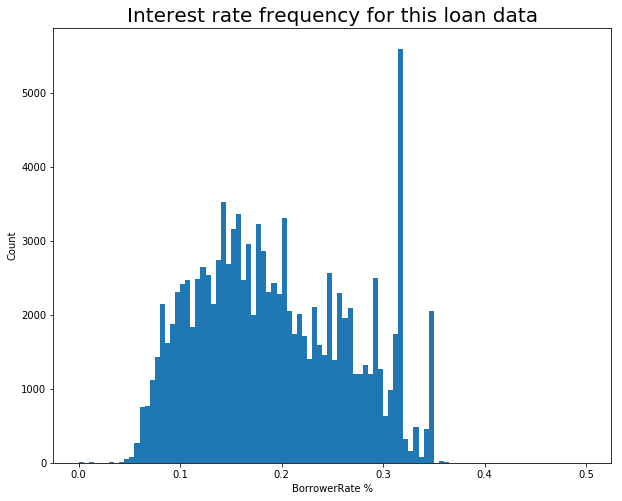

```python
#interest rate frequency plot
plot_attributes()
binsize = 0.005

#setting the binedges
bins = np.arange(0, loan_clean['BorrowerRate'].max()+binsize, binsize)

plt.hist(data = loan_clean, x = 'BorrowerRate', bins = bins)

plt.title('Interest rate frequency for this loan data', {'fontsize':20})
plt.xlabel('BorrowerRate %')
plt.ylabel('Count');
```

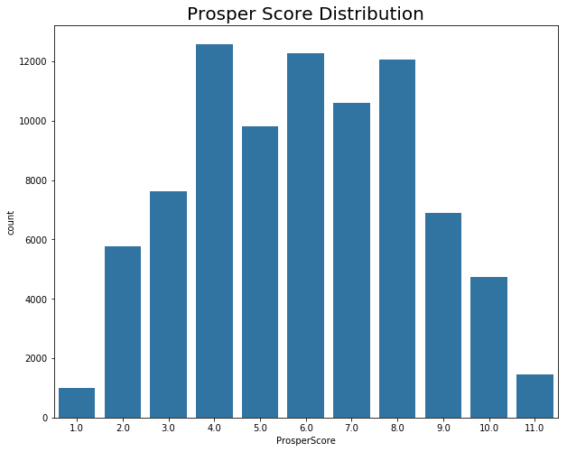

```python
#prosper score distribution
plot_attributes()
sb.countplot(data = loan_clean, x = 'ProsperScore', color = base_color)
plt.title('Prosper Score Distribution', {'fontsize':20})
plt.show();
```

> The Prosper Score Distribution shows 4, 6, 8 were the most common scores in this loan application.

```python
#verifying the value counts of the credit grade
loan_clean['CreditGrade'].value_counts()
```

```
C     5649
D     5153
B     4389
AA    3509
HR    3508
A     3315
E     3289
NC     141
Name: CreditGrade, dtype: int64
```

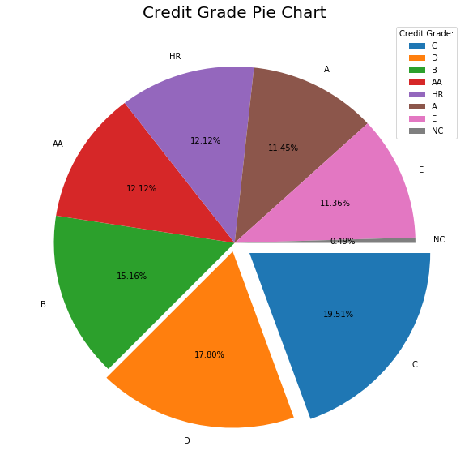

```python
#plotting the credit grade on a pie chart
plt.figure(figsize=[10, 10])

sorted_index = loan_clean['CreditGrade'].value_counts()

plt.pie(sorted_index, labels = sorted_index.index, counterclock = False, autopct='%1.2f%%',
        explode=[0.1, 0.05, 0, 0, 0, 0, 0, 0])
plt.title('Credit Grade Pie Chart', {'fontsize':20})
plt.legend(title = 'Credit Grade:')
plt.show();
```

> The pie chart shows the credit grade that had the largest ratio which is the C credit grade. I also exploded it to make it more visible

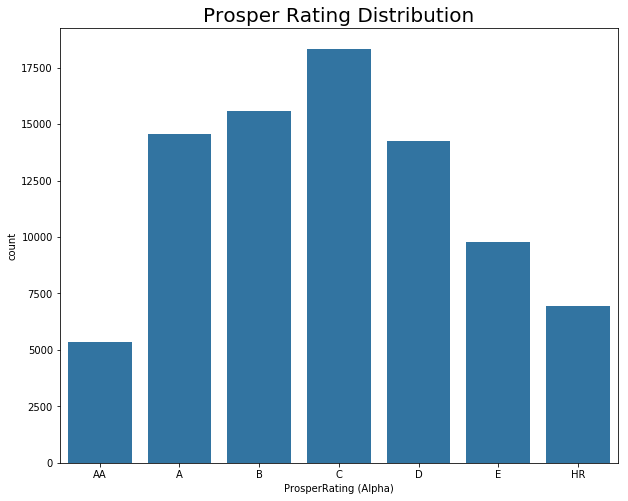

```python
#prosper rating distribution
plot_attributes()
sb.countplot(data = loan_clean, x = 'ProsperRating (Alpha)', color = base_color)
plt.title('Prosper Rating Distribution', {'fontsize': 20})
plt.show();
```

> From the pie chart we can see that credit grade C has the largest distribution in this dataset followed by D and they've been exploded from the chart for more clarity. Also, if you observe the ProsperRating (Alpha) Distribution closely, you'll notice there is a correlation between the `CreditGrade` and `ProsperRating`

```python
#confirming the income range value counts
loan_clean['IncomeRange'].value_counts()
```

```
$25,000-49,999    32192
$50,000-74,999    31050
$100,000+         17337
$75,000-99,999    16916
$1-24,999          7274
$0                  621
Name: IncomeRange, dtype: int64
```

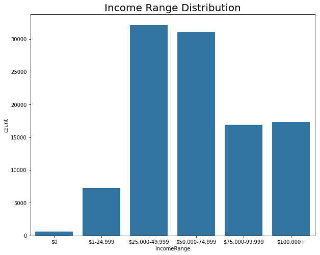

```python
#income range distribution plot
plot_attributes()

sb.countplot(data = loan_clean, x = 'IncomeRange', color = base_color)
plt.title('Income Range Distribution', {'fontsize': 20})
plt.show();
```

> Income range from `$25,000-49,999` ahad the most applications followed by `$50,000-74999`

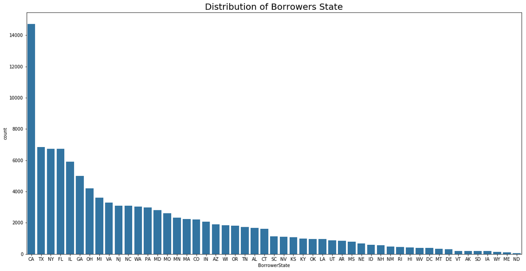

```python
#Borrower state plot
plt.figure(figsize = [20, 10])

high_order = loan_clean['BorrowerState'].value_counts().index
sb.countplot(data = loan_clean, x = 'BorrowerState', color = base_color, order=high_order)

plt.title('Distribution of Borrowers State', {'fontsize':20})
plt.show();
```

> The most loan applications came from people from `California`

```python
#verifying the value counts for the loan status
loan_clean['LoanStatus'].value_counts()
```

```
Current                   56576
Completed                 38074
Chargedoff                11992
Defaulted                  5018
Past Due (1-15 days)        806
Past Due (31-60 days)       363
Past Due (61-90 days)       313
Past Due (91-120 days)      304
Past Due (16-30 days)       265
FinalPaymentInProgress      205
Past Due (>120 days)         16
Cancelled                     5
Name: LoanStatus, dtype: int64
```

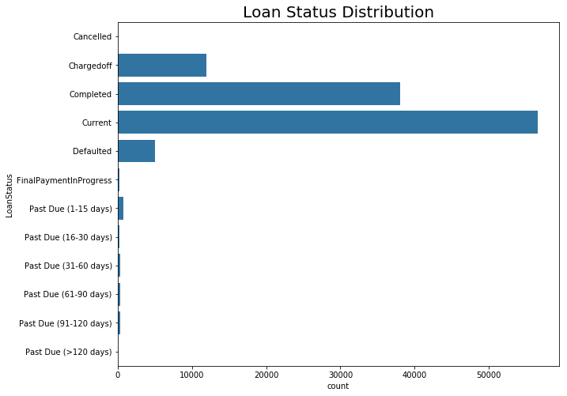

```python
#plotting the loan status distribution
plot_attributes()

sb.countplot(data = loan_clean, y = 'LoanStatus', color = base_color)

plt.title('Loan Status Distribution', {'fontsize':20})
plt.show();
```

> From the visualizations above we have almost 40000 `completed` loans while almost half of the loan applications are at the `current`

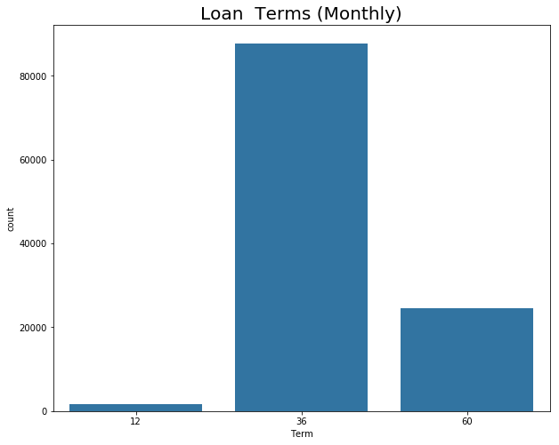

```python
#loan terms plot
plot_attributes()
sb.countplot(data = loan_clean, x = 'Term', color = base_color)
plt.title('Loan  Terms (Monthly)', {'fontsize':20})
plt.show();
```

> Most of the Loan Terms values are in 36 months(3 Years)

```python
#filling the missing value of BorrowerAPR with the mean of the column as it will be needed later on
loan_clean['BorrowerAPR'].fillna(loan_clean['BorrowerAPR'].mean(), inplace = True)

loan_clean['BorrowerAPR'].isna().sum()
```

```
0
```

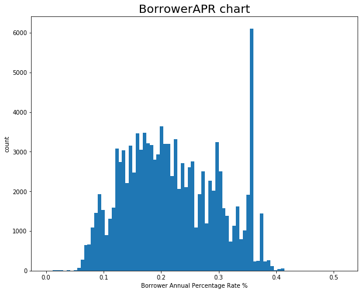

```python
#borrower apr plot
plot_attributes()

#setting binedges
binsize = 0.006
bins = np.arange(0, loan_clean['BorrowerAPR'].max()+binsize, binsize)

plt.hist(data = loan_clean, x = 'BorrowerAPR', bins = bins)

plt.title('BorrowerAPR chart', {'fontsize':20})
plt.xlabel('Borrower Annual Percentage Rate %')
plt.ylabel('count')
plt.show();
```

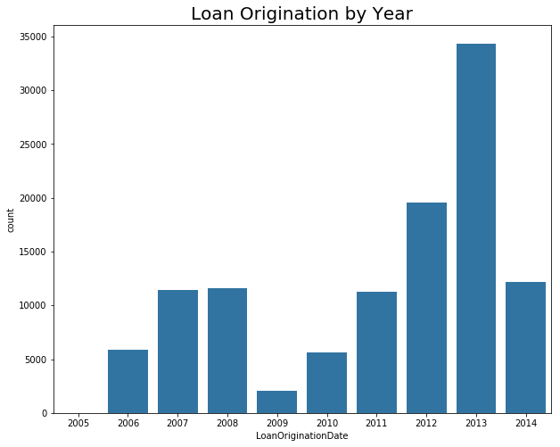

```python
#loan origination by year
plot_attributes()

sb.countplot(data = loan_clean , x = loan_clean['LoanOriginationDate'].dt.year, color =  base_color)

plt.title('Loan Origination by Year', {'fontsize':20})
plt.show();
```

> The most Loans were originated in the year 2013 with 2012 being the second highest year which loans were originated

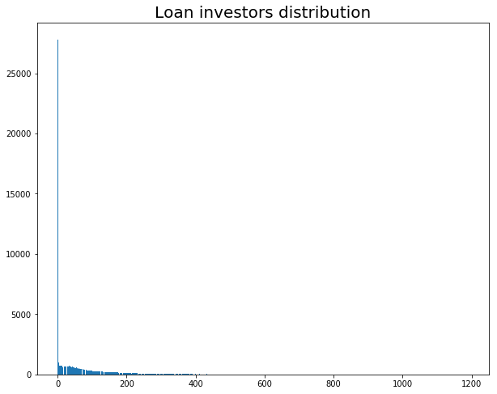

```python
#the loan investor distribution plot
plot_attributes()
binsize = 0.9
bins = np.arange(0, loan_clean['Investors'].max()+binsize, binsize)

plt.hist(data = loan_clean, x = 'Investors', bins= bins)
plt.title('Loan investors distribution', {'fontsize':20})
plt.show();
```

> The investors plot is skewed to the right and has a very long tail which might contain some information that might be valuable. So i'll be transforming the plot with a log scale to see if i can obtain more information from the plot.

```python
#checking out the statistical information of the investors feature
np.log10(loan_clean['Investors'].describe())
```

```
count    5.056665
mean     1.905662
std      2.013844
min      0.000000
25%      0.301030
50%      1.643453
75%      2.060698
max      3.075182
Name: Investors, dtype: float64
```

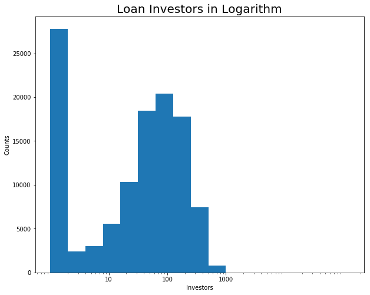

```python
#putting the loan investors on a logarithm scale to view hidden information in long tail
plot_attributes()

bins = 10 ** np.arange(0, 5+0.3, 0.3)
plt.hist(data = loan_clean, x= 'Investors', bins = bins)


plt.xscale('log')
plt.title('Loan Investors in Logarithm', {'fontsize':20})
plt.xticks([1e1, 1e2, 1e3], ['10', '100', '1000'])
plt.xlabel('Investors')
plt.ylabel('Counts')
plt.show();
```

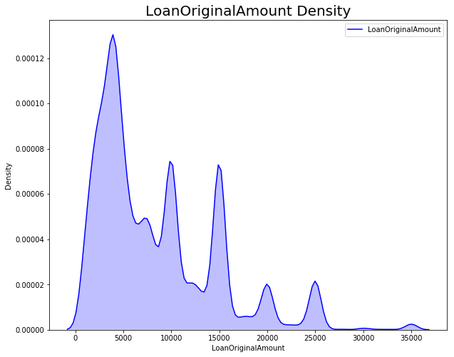

```python
#density of loan original amount
plot_attributes()


sb.kdeplot(loan_clean['LoanOriginalAmount'], shade=True, color="b")
plt.xlabel('LoanOriginalAmount')
plt.ylabel('Density')
plt.title('LoanOriginalAmount Density', {'fontsize': 20});
```

> From the plot above we can see the density of the LoanOriginalAmount

### Discuss the distribution(s) of your variable(s) of interest. Were there any unusual points? Did you need to perform any transformations?

> The Loan investors distribution was skewed to the right and had a long tail. I had to perform a logarithm scalling to be able to view further information in the long tail.

### Of the features you investigated, were there any unusual distributions? Did you perform any operations on the data to tidy, adjust, or change the form of the data? If so, why did you do this?

> Some of the data had missing values so I had to fill some by using the mean of the column, and others i just filled with 0s. Also, i did some datatype cleaning.

> **Rubric Tip**: Visualizations should depict the data appropriately so that the plots are easily interpretable. You should choose an appropriate plot type, data encodings, and formatting as needed. The formatting may include setting/adding the title, labels, legend, and comments. Also, do not overplot or incorrectly plot ordinal data.

## Bivariate Exploration

> In this section, investigate relationships between pairs of variables in your data. Make sure the variables that you cover here have been introduced in some fashion in the previous section (univariate exploration).

```python
#statistical information of the borrower rate
loan_clean['BorrowerRate'].describe()
```

```
count    113937.000000
mean          0.192764
std           0.074818
min           0.000000
25%           0.134000
50%           0.184000
75%           0.250000
max           0.497500
Name: BorrowerRate, dtype: float64
```

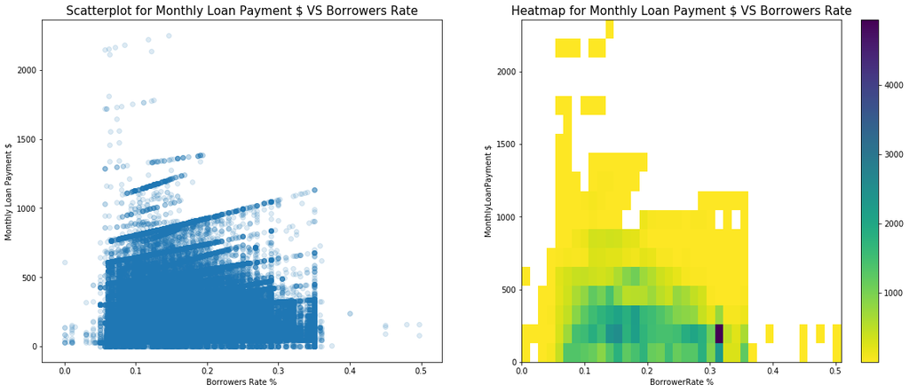

```python
#scatterplot and heatmap for the borrower rate distribution
plt.figure(figsize=[20, 8])

plt.subplot(1,2,1)
plt.scatter(data = loan_clean, x = 'BorrowerRate', y = 'MonthlyLoanPayment', alpha = 3/20)
plt.xlabel('Borrowers Rate %')
plt.ylabel('Monthly Loan Payment $')
plt.title('Scatterplot for Monthly Loan Payment $ VS Borrowers Rate', {'fontsize':15})

plt.subplot(1,2,2)
bins_x = np.arange(0, loan_clean['BorrowerRate'].max()+0.0134, 0.0134)
bins_y = np.arange(0, loan_clean['MonthlyLoanPayment'].max()+131, 131)
plt.hist2d(data = loan_clean, x = 'BorrowerRate', y = 'MonthlyLoanPayment', cmin=0.5, cmap = 'viridis_r',
          bins = [bins_x, bins_y])
plt.colorbar()
plt.title('Heatmap for Monthly Loan Payment $ VS Borrowers Rate', {'fontsize':15})
plt.xlabel('BorrowerRate %')
plt.ylabel('MonthlyLoanPayment $')
plt.show();
```

> From the plots we can see that people whose Monthly loan payment is higher have a low borrower rate percent

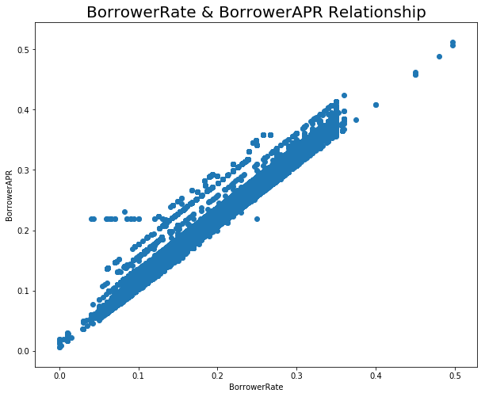

```python
#borrower rate and borrower apr correlation plot
plt.figure(figsize=[10, 8])

plt.scatter(data = loan_clean, x = 'BorrowerRate', y = 'BorrowerAPR')
plt.title('BorrowerRate & BorrowerAPR Relationship', {'fontsize':20})
plt.xlabel('BorrowerRate')
plt.ylabel('BorrowerAPR')
plt.show();
```

The scatterplot shows there is a strong positive relationship between the `BorrowerRate` and `BorrowerAPR`

[figure not shown]

```python
#violin plot showing the prosperscore and loanstatus distribution
plt.figure(figsize=[20, 10])

sb.violinplot(data = loan_clean, x = 'EmploymentStatus', y = 'ProsperScore', color=base_color)
plt.title('ProsperScore & LoanStatus', {'fontsize':20})
plt.xticks(rotation = 45);
```

> Violin plots showing the ProsperScore of the Loan applicants by their different Employment status

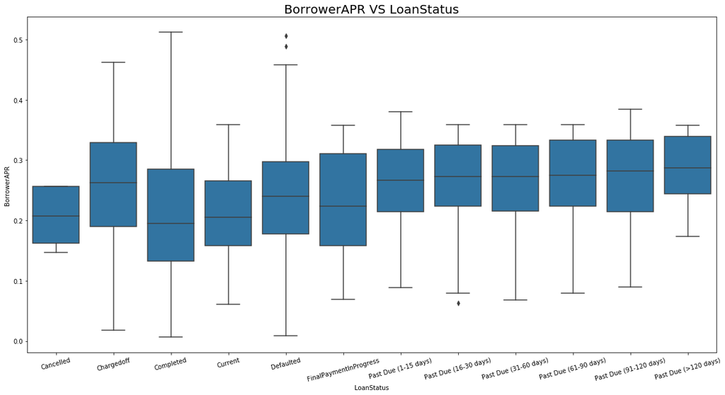

```python
#borrowerapr and loanstatus plot
plt.figure(figsize=[20, 10])

sb.boxplot(data = loan_clean, x = 'LoanStatus', y = 'BorrowerAPR', color = base_color)
plt.xticks(rotation = 15)
plt.title('BorrowerAPR VS LoanStatus', {'fontsize':20})
plt.show();
```

> - From the boxplot we can see that the completed status and the FinalPaymentInPrgoress have the largest IQR
> - Then we can also see the outliers in the Defaulted status
> - There seem to be something that was quite noticeable in this plot, as the past due days increases, the percentage rate also increases

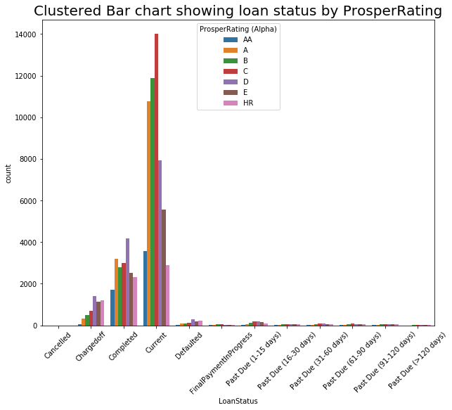

```python
#showing the loan status by prosper rating on a clustered bar chat
plt.figure(figsize=[10, 8])
sb.countplot(data = loan_clean, x = 'LoanStatus', hue = 'ProsperRating (Alpha)')
plt.xticks(rotation=45)
plt.title('Clustered Bar chart showing loan status by ProsperRating', {'fontsize':20})
plt.show();
```

> The clustered barchart shows the loan status by prosper rating and we can see the distribution of how the Prosper rating is related to the outcome of application.

### Talk about some of the relationships you observed in this part of the investigation. How did the feature(s) of interest vary with other features in the dataset?

> The BorrowerAPR was one feature in the dataset that was able to provide the most insghts and showed correlations with a number of other features

## Multivariate Exploration

> Create plots of three or more variables to investigate your data even further. Make sure that your investigations are justified, and follow from your work in the previous sections.

```python
#putting the numeric features in my dataset in a list for feature reference
numeric_values = ['Term', 'BorrowerAPR', 'BorrowerRate', 'LenderYield', 'ProsperScore', 'AmountDelinquent',
                           'StatedMonthlyIncome', 'LoanOriginalAmount', 'MonthlyLoanPayment', 'Investors']

numeric_values
```

```
['Term',
 'BorrowerAPR',
 'BorrowerRate',
 'LenderYield',
 'ProsperScore',
 'AmountDelinquent',
 'StatedMonthlyIncome',
 'LoanOriginalAmount',
 'MonthlyLoanPayment',
 'Investors']
```

```python
#dealing with some null values by filling them with 0s
loan_clean['ProsperScore'].fillna(0, inplace=True)
loan_clean['AmountDelinquent'].fillna(0, inplace=True)

loan_clean['AmountDelinquent'].isna().sum()
```

```
0
```

```python
#correlation table for my data
loan_clean.corr()
```

|  | Term | BorrowerAPR | BorrowerRate | LenderYield | ProsperScore | AmountDelinquent | StatedMonthlyIncome | LoanOriginalAmount | MonthlyLoanPayment | Investors |
| --- | --- | --- | --- | --- | --- | --- | --- | --- | --- | --- |
| Term | 1.000000 | -0.011183 | 0.020085 | 0.020556 | 0.229886 | -0.011916 | 0.028479 | 0.338927 | 0.091026 | -0.045137 |
| BorrowerAPR | -0.011183 | 1.000000 | 0.989587 | 0.989095 | -0.225122 | 0.066167 | -0.082328 | -0.322859 | -0.226627 | -0.307588 |
| BorrowerRate | 0.020085 | 0.989587 | 1.000000 | 0.999211 | -0.288513 | 0.064091 | -0.088982 | -0.328960 | -0.244742 | -0.274217 |
| LenderYield | 0.020556 | 0.989095 | 0.999211 | 1.000000 | -0.288660 | 0.063444 | -0.088208 | -0.328455 | -0.244214 | -0.274174 |
| ProsperScore | 0.229886 | -0.225122 | -0.288513 | -0.288660 | 1.000000 | -0.017653 | 0.107289 | 0.303611 | 0.226234 | -0.000274 |
| AmountDelinquent | -0.011916 | 0.066167 | 0.064091 | 0.063444 | -0.017653 | 1.000000 | 0.009625 | -0.032648 | -0.024014 | -0.025315 |
| StatedMonthlyIncome | 0.028479 | -0.082328 | -0.088982 | -0.088208 | 0.107289 | 0.009625 | 1.000000 | 0.201259 | 0.196830 | 0.076244 |
| LoanOriginalAmount | 0.338927 | -0.322859 | -0.328960 | -0.328455 | 0.303611 | -0.032648 | 0.201259 | 1.000000 | 0.931984 | 0.380093 |
| MonthlyLoanPayment | 0.091026 | -0.226627 | -0.244742 | -0.244214 | 0.226234 | -0.024014 | 0.196830 | 0.931984 | 1.000000 | 0.387409 |
| Investors | -0.045137 | -0.307588 | -0.274217 | -0.274174 | -0.000274 | -0.025315 | 0.076244 | 0.380093 | 0.387409 | 1.000000 |

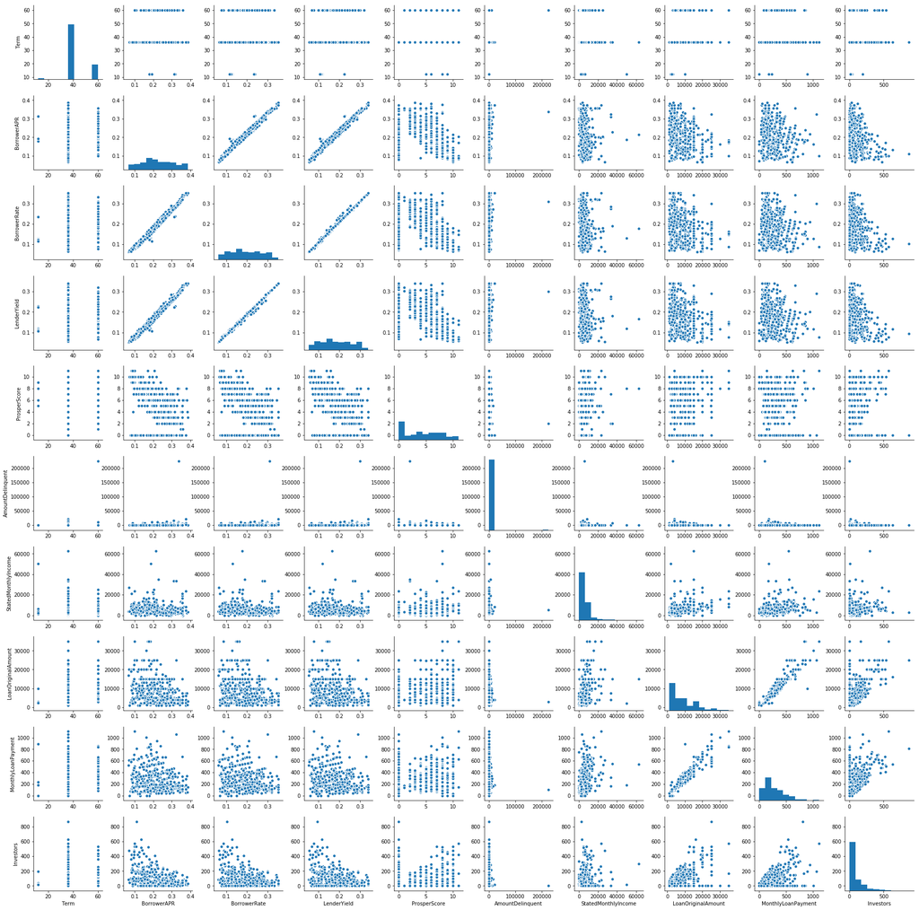

```python
#i tried running the pairplot on all my data but it took time to run, so i decided to
#randomly run it for like 500 samples

samples = np.random.choice(loan_clean.shape[0], 500, replace = False)
loan_clean_sample = loan_clean.loc[samples,:]

sb.pairplot(data = loan_clean_sample, vars = numeric_values);
```

> Here we can see the correlations between the numeric columns in our dataset

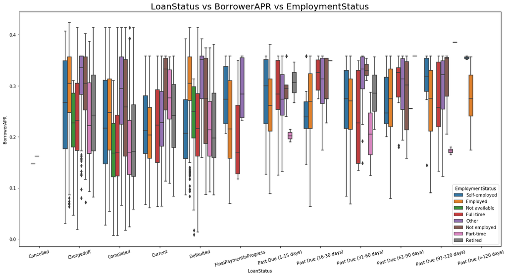

```python
#box plot for LoanStatus vs BorrowerAPR vs EmploymentStatus
plt.figure(figsize=[20, 10])

sb.boxplot(data = loan_clean, x = 'LoanStatus', y = 'BorrowerAPR', hue = 'EmploymentStatus')
plt.xticks(rotation=15)
plt.title('LoanStatus vs BorrowerAPR vs EmploymentStatus', {'fontsize':20})
plt.show();
```

> - This plot shows the Loanstatus BorrowerAPR using the Employment Status class.
> - We can notice some outliers ib Chargedoff and Defaulted

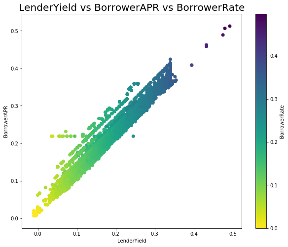

```python
#lenderyield, borrowerAPR, borrowerrate scatterplot correlation plot
plt.figure(figsize=[10, 8])

plt.scatter(data = loan_clean, x = 'LenderYield', y = 'BorrowerAPR', c = 'BorrowerRate', cmap = 'viridis_r')
plt.colorbar(label = 'BorrowerRate')
plt.xlabel('LenderYield')
plt.ylabel('BorrowerAPR')
plt.title('LenderYield vs BorrowerAPR vs BorrowerRate', {'fontsize':20})
plt.show();
```

> We can see that the LenderYield vs BorrowerAPR vs BorrowerRate plot shows a very strong positive correlation between themselves.

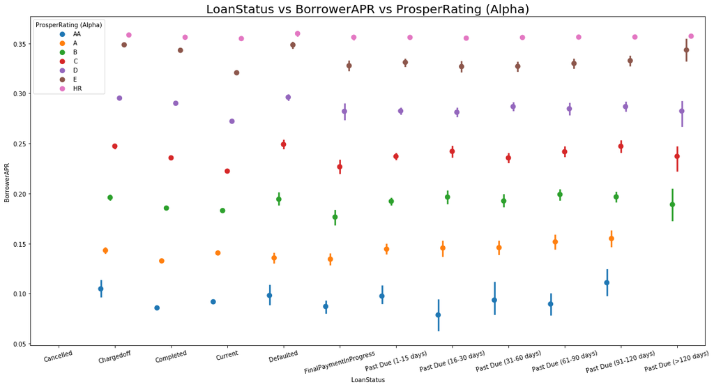

```python
#pointplot display of LoanStatus vs BorrowerAPR vs ProsperRating (Alpha)
plt.figure(figsize=[20, 10])

sb.pointplot(data = loan_clean, x = 'LoanStatus', y = 'BorrowerAPR', hue = 'ProsperRating (Alpha)',
            dodge = 0.5, linestyles = "")
plt.xticks(rotation = 15)
plt.title('LoanStatus vs BorrowerAPR vs ProsperRating (Alpha)', {'fontsize':20})
plt.show();
```

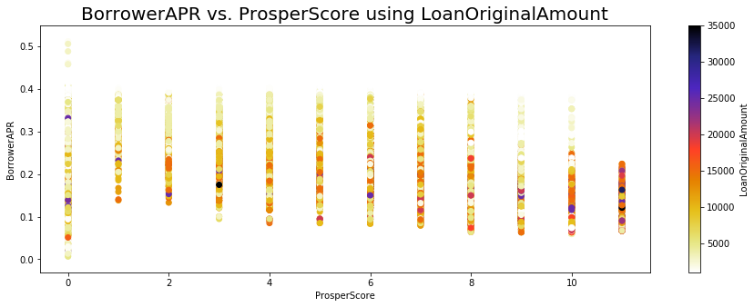

```python
#scatterplot showing BorrowerAPR vs. ProsperScore using LoanOriginalAmount
plt.figure(figsize = [15, 5])
cm = plt.cm.get_cmap('CMRmap_r')
plt.scatter(data=loan_clean[loan_clean['StatedMonthlyIncome']<20000],x='ProsperScore',y='BorrowerAPR',c='LoanOriginalAmount',cmap=cm)
plt.colorbar(label = 'LoanOriginalAmount')
plt.title('BorrowerAPR vs. ProsperScore using LoanOriginalAmount', {'fontsize':20})
plt.xlabel('ProsperScore')
plt.ylabel('BorrowerAPR');
```

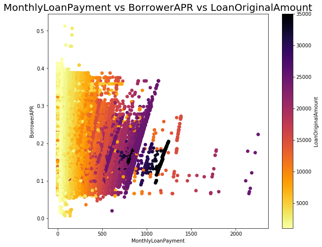

```python
#LoanOriginalAmount relationship with the MonthlyLoanPayment and BorrowerAPR
plt.figure(figsize=(10, 8))

plt.scatter(data = loan_clean, x = 'MonthlyLoanPayment', y = 'BorrowerAPR', c = 'LoanOriginalAmount',
           cmap = 'inferno_r')
plt.title('MonthlyLoanPayment vs BorrowerAPR vs LoanOriginalAmount', {'fontsize':20})
plt.xlabel('MonthlyLoanPayment')
plt.ylabel('BorrowerAPR')
plt.colorbar(label = 'LoanOriginalAmount');
```

### Talk about some of the relationships you observed in this part of the investigation. Were there features that strengthened each other in terms of looking at your feature(s) of interest?

> The Lenderyield, BorrowerAPR and Borrower Rate show a strong positive correlation.

### Were there any interesting or surprising interactions between features?

> My plots were quite okay, i didn't encounter any surprising interactions between my features

## Conclusions

> Remove all Tips mentioned above, before you convert this notebook to PDF/HTML

> At the end of your report, make sure that you export the notebook as an html file from the `File > Download as... > HTML or PDF` menu. Make sure you keep track of where the exported file goes, so you can put it in the same folder as this notebook for project submission. Also, make sure you remove all of the quote-formatted guide notes like this one before you finish your report!